# Risk Factor Analysis

## Outcome Variable

**Outcome Variable:** pers_wast

## Predictor Variables

**Intervention Variable:** feducyrs

**Adjustment Set:**

- arm
- W_mage
- meducyrs
- hhwealth_quart
- W_mhtcm
- W_gagebrth
- W_birthwt
- W_birthlen
- impsan
- delta_W_mage
- delta_meducyrs
- delta_hhwealth_quart
- delta_W_mhtcm
- delta_W_gagebrth
- delta_W_birthwt
- delta_W_birthlen
- delta_impsan

## Stratifying Variables

The analysis was stratified on these variable(s):

- agecat
- studyid
- country

## Data Summary

| agecat | studyid | country | feducyrs | pers_wast | n_cell | n |
| --- | --- | --- | --- | --- | --- | --- |
| 0-24 months | ki0047075b-MAL-ED | BANGLADESH | Low | 0 | 38 | 138 |
| 0-24 months | ki0047075b-MAL-ED | BANGLADESH | Low | 1 | 0 | 138 |
| 0-24 months | ki0047075b-MAL-ED | BANGLADESH | Medium | 0 | 45 | 138 |
| 0-24 months | ki0047075b-MAL-ED | BANGLADESH | Medium | 1 | 4 | 138 |
| 0-24 months | ki0047075b-MAL-ED | BANGLADESH | High | 0 | 48 | 138 |
| 0-24 months | ki0047075b-MAL-ED | BANGLADESH | High | 1 | 3 | 138 |
| 0-24 months | ki0047075b-MAL-ED | INDIA | Low | 0 | 51 | 139 |
| 0-24 months | ki0047075b-MAL-ED | INDIA | Low | 1 | 4 | 139 |
| 0-24 months | ki0047075b-MAL-ED | INDIA | Medium | 0 | 32 | 139 |
| 0-24 months | ki0047075b-MAL-ED | INDIA | Medium | 1 | 9 | 139 |
| 0-24 months | ki0047075b-MAL-ED | INDIA | High | 0 | 43 | 139 |
| 0-24 months | ki0047075b-MAL-ED | INDIA | High | 1 | 0 | 139 |
| 0-24 months | ki0047075b-MAL-ED | NEPAL | Low | 0 | 27 | 96 |
| 0-24 months | ki0047075b-MAL-ED | NEPAL | Low | 1 | 0 | 96 |
| 0-24 months | ki0047075b-MAL-ED | NEPAL | Medium | 0 | 27 | 96 |
| 0-24 months | ki0047075b-MAL-ED | NEPAL | Medium | 1 | 1 | 96 |
| 0-24 months | ki0047075b-MAL-ED | NEPAL | High | 0 | 40 | 96 |
| 0-24 months | ki0047075b-MAL-ED | NEPAL | High | 1 | 1 | 96 |
| 0-24 months | ki0047075b-MAL-ED | PERU | Low | 0 | 63 | 234 |
| 0-24 months | ki0047075b-MAL-ED | PERU | Low | 1 | 0 | 234 |
| 0-24 months | ki0047075b-MAL-ED | PERU | Medium | 0 | 60 | 234 |
| 0-24 months | ki0047075b-MAL-ED | PERU | Medium | 1 | 0 | 234 |
| 0-24 months | ki0047075b-MAL-ED | PERU | High | 0 | 110 | 234 |
| 0-24 months | ki0047075b-MAL-ED | PERU | High | 1 | 1 | 234 |
| 0-24 months | ki0047075b-MAL-ED | SOUTH AFRICA | Low | 0 | 35 | 99 |
| 0-24 months | ki0047075b-MAL-ED | SOUTH AFRICA | Low | 1 | 1 | 99 |
| 0-24 months | ki0047075b-MAL-ED | SOUTH AFRICA | Medium | 0 | 25 | 99 |
| 0-24 months | ki0047075b-MAL-ED | SOUTH AFRICA | Medium | 1 | 0 | 99 |
| 0-24 months | ki0047075b-MAL-ED | SOUTH AFRICA | High | 0 | 38 | 99 |
| 0-24 months | ki0047075b-MAL-ED | SOUTH AFRICA | High | 1 | 0 | 99 |

[output cut: 252 more lines]

The following strata were considered:

- agecat: 0-24 months, studyid: ki0047075b-MAL-ED, country: BANGLADESH
- agecat: 0-24 months, studyid: ki0047075b-MAL-ED, country: INDIA
- agecat: 0-24 months, studyid: ki0047075b-MAL-ED, country: NEPAL
- agecat: 0-24 months, studyid: ki0047075b-MAL-ED, country: PERU
- agecat: 0-24 months, studyid: ki0047075b-MAL-ED, country: SOUTH AFRICA
- agecat: 0-24 months, studyid: ki0047075b-MAL-ED, country: TANZANIA, UNITED REPUBLIC OF
- agecat: 0-24 months, studyid: ki1000304b-SAS-CompFeed, country: INDIA
- agecat: 0-24 months, studyid: ki1000304b-SAS-FoodSuppl, country: INDIA
- agecat: 0-24 months, studyid: ki1017093b-PROVIDE, country: BANGLADESH
- agecat: 0-24 months, studyid: ki1017093c-NIH-Crypto, country: BANGLADESH
- agecat: 0-24 months, studyid: ki1066203-TanzaniaChild2, country: TANZANIA, UNITED REPUBLIC OF
- agecat: 0-24 months, studyid: ki1113344-GMS-Nepal, country: NEPAL
- agecat: 0-24 months, studyid: ki1119695-PROBIT, country: BELARUS
- agecat: 0-24 months, studyid: ki1126311-ZVITAMBO, country: ZIMBABWE
- agecat: 0-24 months, studyid: ki1135781-COHORTS, country: GUATEMALA
- agecat: 0-24 months, studyid: ki1135781-COHORTS, country: INDIA
- agecat: 0-24 months, studyid: ki1135781-COHORTS, country: PHILIPPINES
- agecat: 0-24 months, studyid: ki1148112-LCNI-5, country: MALAWI
- agecat: 0-24 months, studyid: kiGH5241-JiVitA-3, country: BANGLADESH
- agecat: 0-24 months, studyid: kiGH5241-JiVitA-4, country: BANGLADESH
- agecat: 0-6 months, studyid: ki0047075b-MAL-ED, country: BANGLADESH
- agecat: 0-6 months, studyid: ki0047075b-MAL-ED, country: INDIA
- agecat: 0-6 months, studyid: ki0047075b-MAL-ED, country: NEPAL
- agecat: 0-6 months, studyid: ki0047075b-MAL-ED, country: PERU
- agecat: 0-6 months, studyid: ki0047075b-MAL-ED, country: SOUTH AFRICA
- agecat: 0-6 months, studyid: ki0047075b-MAL-ED, country: TANZANIA, UNITED REPUBLIC OF
- agecat: 0-6 months, studyid: ki1017093b-PROVIDE, country: BANGLADESH
- agecat: 0-6 months, studyid: ki1066203-TanzaniaChild2, country: TANZANIA, UNITED REPUBLIC OF
- agecat: 0-6 months, studyid: ki1113344-GMS-Nepal, country: NEPAL
- agecat: 6-24 months, studyid: ki0047075b-MAL-ED, country: BANGLADESH
- agecat: 6-24 months, studyid: ki0047075b-MAL-ED, country: INDIA
- agecat: 6-24 months, studyid: ki0047075b-MAL-ED, country: NEPAL
- agecat: 6-24 months, studyid: ki0047075b-MAL-ED, country: PERU
- agecat: 6-24 months, studyid: ki0047075b-MAL-ED, country: SOUTH AFRICA
- agecat: 6-24 months, studyid: ki0047075b-MAL-ED, country: TANZANIA, UNITED REPUBLIC OF
- agecat: 6-24 months, studyid: ki1000304b-SAS-CompFeed, country: INDIA
- agecat: 6-24 months, studyid: ki1000304b-SAS-FoodSuppl, country: INDIA
- agecat: 6-24 months, studyid: ki1017093b-PROVIDE, country: BANGLADESH
- agecat: 6-24 months, studyid: ki1017093c-NIH-Crypto, country: BANGLADESH
- agecat: 6-24 months, studyid: ki1066203-TanzaniaChild2, country: TANZANIA, UNITED REPUBLIC OF
- agecat: 6-24 months, studyid: ki1113344-GMS-Nepal, country: NEPAL
- agecat: 6-24 months, studyid: ki1119695-PROBIT, country: BELARUS
- agecat: 6-24 months, studyid: ki1126311-ZVITAMBO, country: ZIMBABWE
- agecat: 6-24 months, studyid: ki1135781-COHORTS, country: GUATEMALA
- agecat: 6-24 months, studyid: ki1135781-COHORTS, country: PHILIPPINES
- agecat: 6-24 months, studyid: ki1148112-LCNI-5, country: MALAWI
- agecat: 6-24 months, studyid: kiGH5241-JiVitA-4, country: BANGLADESH

### Dropped Strata

Some strata were dropped due to rare outcomes:

- agecat: 0-24 months, studyid: ki0047075b-MAL-ED, country: BANGLADESH
- agecat: 0-24 months, studyid: ki0047075b-MAL-ED, country: INDIA
- agecat: 0-24 months, studyid: ki0047075b-MAL-ED, country: NEPAL
- agecat: 0-24 months, studyid: ki0047075b-MAL-ED, country: PERU
- agecat: 0-24 months, studyid: ki0047075b-MAL-ED, country: SOUTH AFRICA
- agecat: 0-24 months, studyid: ki0047075b-MAL-ED, country: TANZANIA, UNITED REPUBLIC OF
- agecat: 0-24 months, studyid: ki1017093b-PROVIDE, country: BANGLADESH
- agecat: 0-24 months, studyid: ki1017093c-NIH-Crypto, country: BANGLADESH
- agecat: 0-24 months, studyid: ki1148112-LCNI-5, country: MALAWI
- agecat: 0-6 months, studyid: ki0047075b-MAL-ED, country: BANGLADESH
- agecat: 0-6 months, studyid: ki0047075b-MAL-ED, country: INDIA
- agecat: 0-6 months, studyid: ki0047075b-MAL-ED, country: NEPAL
- agecat: 0-6 months, studyid: ki0047075b-MAL-ED, country: PERU
- agecat: 0-6 months, studyid: ki0047075b-MAL-ED, country: SOUTH AFRICA
- agecat: 0-6 months, studyid: ki0047075b-MAL-ED, country: TANZANIA, UNITED REPUBLIC OF
- agecat: 0-6 months, studyid: ki1017093b-PROVIDE, country: BANGLADESH
- agecat: 6-24 months, studyid: ki0047075b-MAL-ED, country: BANGLADESH
- agecat: 6-24 months, studyid: ki0047075b-MAL-ED, country: INDIA
- agecat: 6-24 months, studyid: ki0047075b-MAL-ED, country: NEPAL
- agecat: 6-24 months, studyid: ki0047075b-MAL-ED, country: PERU
- agecat: 6-24 months, studyid: ki0047075b-MAL-ED, country: SOUTH AFRICA
- agecat: 6-24 months, studyid: ki0047075b-MAL-ED, country: TANZANIA, UNITED REPUBLIC OF
- agecat: 6-24 months, studyid: ki1119695-PROBIT, country: BELARUS
- agecat: 6-24 months, studyid: ki1148112-LCNI-5, country: MALAWI

## Methods Detail

We’re interested in the causal parameters $E[Y_a]$ for all values of $a \in \mathcal{A}$. These parameters represent the mean outcome if, possibly contrary to fact, we intervened to set all units to have $A=a$. Under the randomization and positivity assumptions, these are identified by the statistical parameters $\psi_a=E_W[E_{Y|A,W}(Y|A=a,W)]$. In addition, we’re interested in the mean of $Y$, $E[Y]$ under no intervention (the observed mean). We will estimate these parameters by using SuperLearner to fit the relevant likelihood factors – $E_{Y|A,W}(Y|A=a,W)$ and $p(A=a|W)$, and then updating our likelihood fit using a joint TMLE.

For unadjusted analyses ($W=\{\}$), initial likelihoods were estimated using Lrnr_glm to estimate the simple $E(Y|A)$ and Lrnr_mean to estimate $p(A)$. For adjusted analyses, a small library containing Lrnr_glmnet, Lrnr_xgboost, and Lrnr_mean was used.

Having estimated these parameters, we will then use the delta method to estimate relative risks and attributable risks relative to a prespecified baseline level of $A$.

# Results Detail

## Results Plots

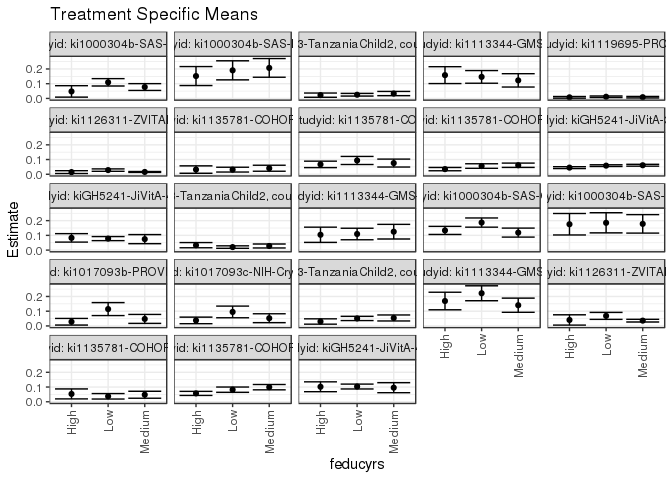

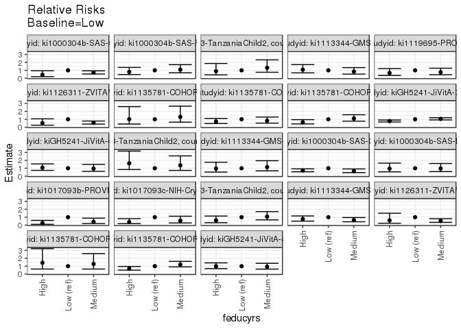

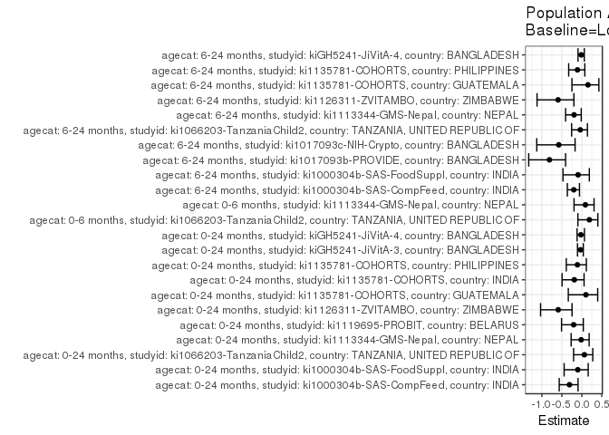

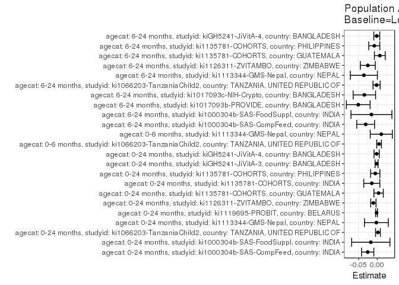

## Results Table

### Parameter: TSM

| agecat | studyid | country | intervention_level | baseline_level | estimate | ci_lower | ci_upper |
| --- | --- | --- | --- | --- | --- | --- | --- |
| 0-24 months | ki1000304b-SAS-CompFeed | INDIA | Low | NA | 0.1094575 | 0.0844567 | 0.1344583 |
| 0-24 months | ki1000304b-SAS-CompFeed | INDIA | Medium | NA | 0.0775239 | 0.0544276 | 0.1006203 |
| 0-24 months | ki1000304b-SAS-CompFeed | INDIA | High | NA | 0.0476368 | 0.0088918 | 0.0863817 |
| 0-24 months | ki1000304b-SAS-FoodSuppl | INDIA | Low | NA | 0.1908141 | 0.1260395 | 0.2555887 |
| 0-24 months | ki1000304b-SAS-FoodSuppl | INDIA | Medium | NA | 0.2073163 | 0.1439310 | 0.2707016 |
| 0-24 months | ki1000304b-SAS-FoodSuppl | INDIA | High | NA | 0.1519359 | 0.0875698 | 0.2163021 |
| 0-24 months | ki1066203-TanzaniaChild2 | TANZANIA, UNITED REPUBLIC OF | Low | NA | 0.0251736 | 0.0161255 | 0.0342217 |
| 0-24 months | ki1066203-TanzaniaChild2 | TANZANIA, UNITED REPUBLIC OF | Medium | NA | 0.0332779 | 0.0189349 | 0.0476209 |
| 0-24 months | ki1066203-TanzaniaChild2 | TANZANIA, UNITED REPUBLIC OF | High | NA | 0.0223881 | 0.0079228 | 0.0368534 |
| 0-24 months | ki1113344-GMS-Nepal | NEPAL | Low | NA | 0.1462714 | 0.1034188 | 0.1891240 |
| 0-24 months | ki1113344-GMS-Nepal | NEPAL | Medium | NA | 0.1227802 | 0.0774964 | 0.1680640 |
| 0-24 months | ki1113344-GMS-Nepal | NEPAL | High | NA | 0.1581922 | 0.1009415 | 0.2154428 |
| 0-24 months | ki1119695-PROBIT | BELARUS | Low | NA | 0.0114360 | 0.0062549 | 0.0166172 |
| 0-24 months | ki1119695-PROBIT | BELARUS | Medium | NA | 0.0085834 | 0.0034081 | 0.0137587 |
| 0-24 months | ki1119695-PROBIT | BELARUS | High | NA | 0.0075205 | 0.0020341 | 0.0130068 |
| 0-24 months | ki1126311-ZVITAMBO | ZIMBABWE | Low | NA | 0.0284450 | 0.0202527 | 0.0366373 |
| 0-24 months | ki1126311-ZVITAMBO | ZIMBABWE | Medium | NA | 0.0157297 | 0.0127864 | 0.0186730 |
| 0-24 months | ki1126311-ZVITAMBO | ZIMBABWE | High | NA | 0.0148026 | 0.0052031 | 0.0244022 |
| 0-24 months | ki1135781-COHORTS | GUATEMALA | Low | NA | 0.0314607 | 0.0152340 | 0.0476873 |
| 0-24 months | ki1135781-COHORTS | GUATEMALA | Medium | NA | 0.0409836 | 0.0206627 | 0.0613045 |
| 0-24 months | ki1135781-COHORTS | GUATEMALA | High | NA | 0.0319149 | 0.0067764 | 0.0570534 |
| 0-24 months | ki1135781-COHORTS | INDIA | Low | NA | 0.0936991 | 0.0662291 | 0.1211692 |
| 0-24 months | ki1135781-COHORTS | INDIA | Medium | NA | 0.0760255 | 0.0490906 | 0.1029603 |
| 0-24 months | ki1135781-COHORTS | INDIA | High | NA | 0.0671959 | 0.0453934 | 0.0889984 |
| 0-24 months | ki1135781-COHORTS | PHILIPPINES | Low | NA | 0.0559239 | 0.0405889 | 0.0712590 |
| 0-24 months | ki1135781-COHORTS | PHILIPPINES | Medium | NA | 0.0612528 | 0.0466281 | 0.0758775 |
| 0-24 months | ki1135781-COHORTS | PHILIPPINES | High | NA | 0.0350579 | 0.0238595 | 0.0462563 |
| 0-24 months | kiGH5241-JiVitA-3 | BANGLADESH | Low | NA | 0.0586006 | 0.0528196 | 0.0643816 |
| 0-24 months | kiGH5241-JiVitA-3 | BANGLADESH | Medium | NA | 0.0612941 | 0.0549611 | 0.0676271 |
| 0-24 months | kiGH5241-JiVitA-3 | BANGLADESH | High | NA | 0.0452167 | 0.0388681 | 0.0515653 |
| 0-24 months | kiGH5241-JiVitA-4 | BANGLADESH | Low | NA | 0.0782190 | 0.0644488 | 0.0919892 |
| 0-24 months | kiGH5241-JiVitA-4 | BANGLADESH | Medium | NA | 0.0745037 | 0.0437112 | 0.1052962 |
| 0-24 months | kiGH5241-JiVitA-4 | BANGLADESH | High | NA | 0.0831635 | 0.0544114 | 0.1119156 |
| 0-6 months | ki1066203-TanzaniaChild2 | TANZANIA, UNITED REPUBLIC OF | Low | NA | 0.0205520 | 0.0121700 | 0.0289340 |
| 0-6 months | ki1066203-TanzaniaChild2 | TANZANIA, UNITED REPUBLIC OF | Medium | NA | 0.0280560 | 0.0145989 | 0.0415132 |
| 0-6 months | ki1066203-TanzaniaChild2 | TANZANIA, UNITED REPUBLIC OF | High | NA | 0.0334356 | 0.0157956 | 0.0510756 |
| 0-6 months | ki1113344-GMS-Nepal | NEPAL | Low | NA | 0.1093763 | 0.0701889 | 0.1485637 |
| 0-6 months | ki1113344-GMS-Nepal | NEPAL | Medium | NA | 0.1249695 | 0.0753410 | 0.1745980 |
| 0-6 months | ki1113344-GMS-Nepal | NEPAL | High | NA | 0.1040805 | 0.0523236 | 0.1558373 |
| 6-24 months | ki1000304b-SAS-CompFeed | INDIA | Low | NA | 0.1869502 | 0.1558008 | 0.2180996 |
| 6-24 months | ki1000304b-SAS-CompFeed | INDIA | Medium | NA | 0.1188484 | 0.0882777 | 0.1494192 |
| 6-24 months | ki1000304b-SAS-CompFeed | INDIA | High | NA | 0.1336178 | 0.1061359 | 0.1610996 |
| 6-24 months | ki1000304b-SAS-FoodSuppl | INDIA | Low | NA | 0.1853253 | 0.1169867 | 0.2536638 |
| 6-24 months | ki1000304b-SAS-FoodSuppl | INDIA | Medium | NA | 0.1780997 | 0.1154647 | 0.2407348 |
| 6-24 months | ki1000304b-SAS-FoodSuppl | INDIA | High | NA | 0.1755824 | 0.1026849 | 0.2484799 |
| 6-24 months | ki1017093b-PROVIDE | BANGLADESH | Low | NA | 0.1144279 | 0.0703836 | 0.1584721 |
| 6-24 months | ki1017093b-PROVIDE | BANGLADESH | Medium | NA | 0.0476190 | 0.0172330 | 0.0780051 |
| 6-24 months | ki1017093b-PROVIDE | BANGLADESH | High | NA | 0.0284360 | 0.0059900 | 0.0508820 |
| 6-24 months | ki1017093c-NIH-Crypto | BANGLADESH | Low | NA | 0.0950197 | 0.0554154 | 0.1346239 |
| 6-24 months | ki1017093c-NIH-Crypto | BANGLADESH | Medium | NA | 0.0524977 | 0.0222265 | 0.0827688 |
| 6-24 months | ki1017093c-NIH-Crypto | BANGLADESH | High | NA | 0.0375739 | 0.0152978 | 0.0598500 |
| 6-24 months | ki1066203-TanzaniaChild2 | TANZANIA, UNITED REPUBLIC OF | Low | NA | 0.0508038 | 0.0364297 | 0.0651778 |
| 6-24 months | ki1066203-TanzaniaChild2 | TANZANIA, UNITED REPUBLIC OF | Medium | NA | 0.0541838 | 0.0337430 | 0.0746246 |
| 6-24 months | ki1066203-TanzaniaChild2 | TANZANIA, UNITED REPUBLIC OF | High | NA | 0.0300301 | 0.0119224 | 0.0481377 |
| 6-24 months | ki1113344-GMS-Nepal | NEPAL | Low | NA | 0.2218461 | 0.1711550 | 0.2725372 |
| 6-24 months | ki1113344-GMS-Nepal | NEPAL | Medium | NA | 0.1405885 | 0.0924852 | 0.1886917 |
| 6-24 months | ki1113344-GMS-Nepal | NEPAL | High | NA | 0.1692243 | 0.1095998 | 0.2288489 |
| 6-24 months | ki1126311-ZVITAMBO | ZIMBABWE | Low | NA | 0.0683371 | 0.0447283 | 0.0919460 |
| 6-24 months | ki1126311-ZVITAMBO | ZIMBABWE | Medium | NA | 0.0359848 | 0.0268105 | 0.0451592 |
| 6-24 months | ki1126311-ZVITAMBO | ZIMBABWE | High | NA | 0.0406504 | 0.0057430 | 0.0755578 |
| 6-24 months | ki1135781-COHORTS | GUATEMALA | Low | NA | 0.0372208 | 0.0187283 | 0.0557134 |
| 6-24 months | ki1135781-COHORTS | GUATEMALA | Medium | NA | 0.0477707 | 0.0241670 | 0.0713744 |
| 6-24 months | ki1135781-COHORTS | GUATEMALA | High | NA | 0.0532544 | 0.0193822 | 0.0871267 |
| 6-24 months | ki1135781-COHORTS | PHILIPPINES | Low | NA | 0.0820398 | 0.0640808 | 0.0999988 |
| 6-24 months | ki1135781-COHORTS | PHILIPPINES | Medium | NA | 0.0991619 | 0.0810513 | 0.1172725 |
| 6-24 months | ki1135781-COHORTS | PHILIPPINES | High | NA | 0.0568330 | 0.0429837 | 0.0706822 |
| 6-24 months | kiGH5241-JiVitA-4 | BANGLADESH | Low | NA | 0.1034037 | 0.0869328 | 0.1198746 |
| 6-24 months | kiGH5241-JiVitA-4 | BANGLADESH | Medium | NA | 0.0956838 | 0.0616256 | 0.1297420 |
| 6-24 months | kiGH5241-JiVitA-4 | BANGLADESH | High | NA | 0.1018503 | 0.0682824 | 0.1354183 |

### Parameter: E(Y)

| agecat | studyid | country | intervention_level | baseline_level | estimate | ci_lower | ci_upper |
| --- | --- | --- | --- | --- | --- | --- | --- |
| 0-24 months | ki1000304b-SAS-CompFeed | INDIA | NA | NA | 0.0836390 | 0.0602327 | 0.1070453 |
| 0-24 months | ki1000304b-SAS-FoodSuppl | INDIA | NA | NA | 0.1733333 | 0.1349698 | 0.2116969 |
| 0-24 months | ki1066203-TanzaniaChild2 | TANZANIA, UNITED REPUBLIC OF | NA | NA | 0.0269142 | 0.0200799 | 0.0337484 |
| 0-24 months | ki1113344-GMS-Nepal | NEPAL | NA | NA | 0.1438240 | 0.1155088 | 0.1721392 |
| 0-24 months | ki1119695-PROBIT | BELARUS | NA | NA | 0.0094941 | 0.0051728 | 0.0138153 |
| 0-24 months | ki1126311-ZVITAMBO | ZIMBABWE | NA | NA | 0.0178887 | 0.0151586 | 0.0206188 |
| 0-24 months | ki1135781-COHORTS | GUATEMALA | NA | NA | 0.0350350 | 0.0236276 | 0.0464425 |
| 0-24 months | ki1135781-COHORTS | INDIA | NA | NA | 0.0789050 | 0.0639058 | 0.0939041 |
| 0-24 months | ki1135781-COHORTS | PHILIPPINES | NA | NA | 0.0503949 | 0.0420785 | 0.0587113 |
| 0-24 months | kiGH5241-JiVitA-3 | BANGLADESH | NA | NA | 0.0567315 | 0.0525489 | 0.0609140 |
| 0-24 months | kiGH5241-JiVitA-4 | BANGLADESH | NA | NA | 0.0765009 | 0.0645569 | 0.0884449 |
| 0-6 months | ki1066203-TanzaniaChild2 | TANZANIA, UNITED REPUBLIC OF | NA | NA | 0.0253535 | 0.0185487 | 0.0321583 |
| 0-6 months | ki1113344-GMS-Nepal | NEPAL | NA | NA | 0.1201479 | 0.0927249 | 0.1475708 |
| 6-24 months | ki1000304b-SAS-CompFeed | INDIA | NA | NA | 0.1557036 | 0.1398038 | 0.1716033 |
| 6-24 months | ki1000304b-SAS-FoodSuppl | INDIA | NA | NA | 0.1695402 | 0.1300601 | 0.2090204 |
| 6-24 months | ki1017093b-PROVIDE | BANGLADESH | NA | NA | 0.0632280 | 0.0437545 | 0.0827015 |
| 6-24 months | ki1017093c-NIH-Crypto | BANGLADESH | NA | NA | 0.0602582 | 0.0425793 | 0.0779372 |
| 6-24 months | ki1066203-TanzaniaChild2 | TANZANIA, UNITED REPUBLIC OF | NA | NA | 0.0489098 | 0.0386452 | 0.0591745 |
| 6-24 months | ki1113344-GMS-Nepal | NEPAL | NA | NA | 0.1857639 | 0.1539754 | 0.2175524 |
| 6-24 months | ki1126311-ZVITAMBO | ZIMBABWE | NA | NA | 0.0428705 | 0.0342981 | 0.0514428 |
| 6-24 months | ki1135781-COHORTS | GUATEMALA | NA | NA | 0.0440181 | 0.0305030 | 0.0575331 |
| 6-24 months | ki1135781-COHORTS | PHILIPPINES | NA | NA | 0.0740000 | 0.0637367 | 0.0842633 |
| 6-24 months | kiGH5241-JiVitA-4 | BANGLADESH | NA | NA | 0.1020187 | 0.0880118 | 0.1160257 |

### Parameter: RR

| agecat | studyid | country | intervention_level | baseline_level | estimate | ci_lower | ci_upper |
| --- | --- | --- | --- | --- | --- | --- | --- |
| 0-24 months | ki1000304b-SAS-CompFeed | INDIA | Low | Low | 1.0000000 | 1.0000000 | 1.0000000 |
| 0-24 months | ki1000304b-SAS-CompFeed | INDIA | Medium | Low | 0.7082560 | 0.5354240 | 0.9368772 |
| 0-24 months | ki1000304b-SAS-CompFeed | INDIA | High | Low | 0.4352081 | 0.2001503 | 0.9463190 |
| 0-24 months | ki1000304b-SAS-FoodSuppl | INDIA | Low | Low | 1.0000000 | 1.0000000 | 1.0000000 |
| 0-24 months | ki1000304b-SAS-FoodSuppl | INDIA | Medium | Low | 1.0864833 | 0.6881703 | 1.7153398 |
| 0-24 months | ki1000304b-SAS-FoodSuppl | INDIA | High | Low | 0.7962512 | 0.4647809 | 1.3641180 |
| 0-24 months | ki1066203-TanzaniaChild2 | TANZANIA, UNITED REPUBLIC OF | Low | Low | 1.0000000 | 1.0000000 | 1.0000000 |
| 0-24 months | ki1066203-TanzaniaChild2 | TANZANIA, UNITED REPUBLIC OF | Medium | Low | 1.3219347 | 0.7541879 | 2.3170770 |
| 0-24 months | ki1066203-TanzaniaChild2 | TANZANIA, UNITED REPUBLIC OF | High | Low | 0.8893464 | 0.4245904 | 1.8628236 |
| 0-24 months | ki1113344-GMS-Nepal | NEPAL | Low | Low | 1.0000000 | 1.0000000 | 1.0000000 |
| 0-24 months | ki1113344-GMS-Nepal | NEPAL | Medium | Low | 0.8393999 | 0.5242682 | 1.3439537 |
| 0-24 months | ki1113344-GMS-Nepal | NEPAL | High | Low | 1.0814974 | 0.6792354 | 1.7219901 |
| 0-24 months | ki1119695-PROBIT | BELARUS | Low | Low | 1.0000000 | 1.0000000 | 1.0000000 |
| 0-24 months | ki1119695-PROBIT | BELARUS | Medium | Low | 0.7505574 | 0.4443714 | 1.2677152 |
| 0-24 months | ki1119695-PROBIT | BELARUS | High | Low | 0.6576116 | 0.3536580 | 1.2228001 |
| 0-24 months | ki1126311-ZVITAMBO | ZIMBABWE | Low | Low | 1.0000000 | 1.0000000 | 1.0000000 |
| 0-24 months | ki1126311-ZVITAMBO | ZIMBABWE | Medium | Low | 0.5529857 | 0.3922420 | 0.7796035 |
| 0-24 months | ki1126311-ZVITAMBO | ZIMBABWE | High | Low | 0.5203947 | 0.2559565 | 1.0580338 |
| 0-24 months | ki1135781-COHORTS | GUATEMALA | Low | Low | 1.0000000 | 1.0000000 | 1.0000000 |
| 0-24 months | ki1135781-COHORTS | GUATEMALA | Medium | Low | 1.3026932 | 0.6369794 | 2.6641515 |
| 0-24 months | ki1135781-COHORTS | GUATEMALA | High | Low | 1.0144377 | 0.3956668 | 2.6008847 |
| 0-24 months | ki1135781-COHORTS | INDIA | Low | Low | 1.0000000 | 1.0000000 | 1.0000000 |
| 0-24 months | ki1135781-COHORTS | INDIA | Medium | Low | 0.8113785 | 0.5131507 | 1.2829272 |
| 0-24 months | ki1135781-COHORTS | INDIA | High | Low | 0.7171453 | 0.4637936 | 1.1088928 |
| 0-24 months | ki1135781-COHORTS | PHILIPPINES | Low | Low | 1.0000000 | 1.0000000 | 1.0000000 |
| 0-24 months | ki1135781-COHORTS | PHILIPPINES | Medium | Low | 1.0952886 | 0.7633829 | 1.5715013 |
| 0-24 months | ki1135781-COHORTS | PHILIPPINES | High | Low | 0.6268853 | 0.4119251 | 0.9540208 |
| 0-24 months | kiGH5241-JiVitA-3 | BANGLADESH | Low | Low | 1.0000000 | 1.0000000 | 1.0000000 |
| 0-24 months | kiGH5241-JiVitA-3 | BANGLADESH | Medium | Low | 1.0459630 | 0.9178199 | 1.1919971 |
| 0-24 months | kiGH5241-JiVitA-3 | BANGLADESH | High | Low | 0.7716086 | 0.6579897 | 0.9048468 |
| 0-24 months | kiGH5241-JiVitA-4 | BANGLADESH | Low | Low | 1.0000000 | 1.0000000 | 1.0000000 |
| 0-24 months | kiGH5241-JiVitA-4 | BANGLADESH | Medium | Low | 0.9525012 | 0.6077981 | 1.4926973 |
| 0-24 months | kiGH5241-JiVitA-4 | BANGLADESH | High | Low | 1.0632137 | 0.7290040 | 1.5506408 |
| 0-6 months | ki1066203-TanzaniaChild2 | TANZANIA, UNITED REPUBLIC OF | Low | Low | 1.0000000 | 1.0000000 | 1.0000000 |
| 0-6 months | ki1066203-TanzaniaChild2 | TANZANIA, UNITED REPUBLIC OF | Medium | Low | 1.3651233 | 0.7283079 | 2.5587554 |
| 0-6 months | ki1066203-TanzaniaChild2 | TANZANIA, UNITED REPUBLIC OF | High | Low | 1.6268778 | 0.8352155 | 3.1689203 |
| 0-6 months | ki1113344-GMS-Nepal | NEPAL | Low | Low | 1.0000000 | 1.0000000 | 1.0000000 |
| 0-6 months | ki1113344-GMS-Nepal | NEPAL | Medium | Low | 1.1425654 | 0.6692019 | 1.9507652 |
| 0-6 months | ki1113344-GMS-Nepal | NEPAL | High | Low | 0.9515817 | 0.5151916 | 1.7576138 |
| 6-24 months | ki1000304b-SAS-CompFeed | INDIA | Low | Low | 1.0000000 | 1.0000000 | 1.0000000 |
| 6-24 months | ki1000304b-SAS-CompFeed | INDIA | Medium | Low | 0.6357225 | 0.4443159 | 0.9095850 |
| 6-24 months | ki1000304b-SAS-CompFeed | INDIA | High | Low | 0.7147239 | 0.5547493 | 0.9208309 |
| 6-24 months | ki1000304b-SAS-FoodSuppl | INDIA | Low | Low | 1.0000000 | 1.0000000 | 1.0000000 |
| 6-24 months | ki1000304b-SAS-FoodSuppl | INDIA | Medium | Low | 0.9610117 | 0.5769876 | 1.6006296 |
| 6-24 months | ki1000304b-SAS-FoodSuppl | INDIA | High | Low | 0.9474284 | 0.5442974 | 1.6491360 |
| 6-24 months | ki1017093b-PROVIDE | BANGLADESH | Low | Low | 1.0000000 | 1.0000000 | 1.0000000 |
| 6-24 months | ki1017093b-PROVIDE | BANGLADESH | Medium | Low | 0.4161491 | 0.1975190 | 0.8767765 |
| 6-24 months | ki1017093b-PROVIDE | BANGLADESH | High | Low | 0.2485061 | 0.1032622 | 0.5980435 |
| 6-24 months | ki1017093c-NIH-Crypto | BANGLADESH | Low | Low | 1.0000000 | 1.0000000 | 1.0000000 |
| 6-24 months | ki1017093c-NIH-Crypto | BANGLADESH | Medium | Low | 0.5524926 | 0.2712183 | 1.1254700 |
| 6-24 months | ki1017093c-NIH-Crypto | BANGLADESH | High | Low | 0.3954329 | 0.1917955 | 0.8152809 |
| 6-24 months | ki1066203-TanzaniaChild2 | TANZANIA, UNITED REPUBLIC OF | Low | Low | 1.0000000 | 1.0000000 | 1.0000000 |
| 6-24 months | ki1066203-TanzaniaChild2 | TANZANIA, UNITED REPUBLIC OF | Medium | Low | 1.0665307 | 0.6656173 | 1.7089215 |
| 6-24 months | ki1066203-TanzaniaChild2 | TANZANIA, UNITED REPUBLIC OF | High | Low | 0.5910994 | 0.3036348 | 1.1507193 |
| 6-24 months | ki1113344-GMS-Nepal | NEPAL | Low | Low | 1.0000000 | 1.0000000 | 1.0000000 |
| 6-24 months | ki1113344-GMS-Nepal | NEPAL | Medium | Low | 0.6337207 | 0.4201006 | 0.9559659 |
| 6-24 months | ki1113344-GMS-Nepal | NEPAL | High | Low | 0.7628006 | 0.5016370 | 1.1599319 |
| 6-24 months | ki1126311-ZVITAMBO | ZIMBABWE | Low | Low | 1.0000000 | 1.0000000 | 1.0000000 |
| 6-24 months | ki1126311-ZVITAMBO | ZIMBABWE | Medium | Low | 0.5265783 | 0.3427621 | 0.8089713 |
| 6-24 months | ki1126311-ZVITAMBO | ZIMBABWE | High | Low | 0.5948509 | 0.2357328 | 1.5010543 |
| 6-24 months | ki1135781-COHORTS | GUATEMALA | Low | Low | 1.0000000 | 1.0000000 | 1.0000000 |
| 6-24 months | ki1135781-COHORTS | GUATEMALA | Medium | Low | 1.2834395 | 0.6368903 | 2.5863434 |
| 6-24 months | ki1135781-COHORTS | GUATEMALA | High | Low | 1.4307692 | 0.6383424 | 3.2069004 |
| 6-24 months | ki1135781-COHORTS | PHILIPPINES | Low | Low | 1.0000000 | 1.0000000 | 1.0000000 |
| 6-24 months | ki1135781-COHORTS | PHILIPPINES | Medium | Low | 1.2087044 | 0.9093329 | 1.6066355 |
| 6-24 months | ki1135781-COHORTS | PHILIPPINES | High | Low | 0.6927483 | 0.4994669 | 0.9608248 |
| 6-24 months | kiGH5241-JiVitA-4 | BANGLADESH | Low | Low | 1.0000000 | 1.0000000 | 1.0000000 |
| 6-24 months | kiGH5241-JiVitA-4 | BANGLADESH | Medium | Low | 0.9253418 | 0.6289919 | 1.3613170 |
| 6-24 months | kiGH5241-JiVitA-4 | BANGLADESH | High | Low | 0.9849774 | 0.6862683 | 1.4137043 |

### Parameter: PAR

| agecat | studyid | country | intervention_level | baseline_level | estimate | ci_lower | ci_upper |
| --- | --- | --- | --- | --- | --- | --- | --- |
| 0-24 months | ki1000304b-SAS-CompFeed | INDIA | Low | NA | -0.0258185 | -0.0422932 | -0.0093438 |
| 0-24 months | ki1000304b-SAS-FoodSuppl | INDIA | Low | NA | -0.0174808 | -0.0690100 | 0.0340485 |
| 0-24 months | ki1066203-TanzaniaChild2 | TANZANIA, UNITED REPUBLIC OF | Low | NA | 0.0017405 | -0.0046662 | 0.0081473 |
| 0-24 months | ki1113344-GMS-Nepal | NEPAL | Low | NA | -0.0024474 | -0.0346013 | 0.0297065 |
| 0-24 months | ki1119695-PROBIT | BELARUS | Low | NA | -0.0019420 | -0.0044327 | 0.0005488 |
| 0-24 months | ki1126311-ZVITAMBO | ZIMBABWE | Low | NA | -0.0105563 | -0.0177060 | -0.0034066 |
| 0-24 months | ki1135781-COHORTS | GUATEMALA | Low | NA | 0.0035744 | -0.0090296 | 0.0161783 |
| 0-24 months | ki1135781-COHORTS | INDIA | Low | NA | -0.0147941 | -0.0364261 | 0.0068379 |
| 0-24 months | ki1135781-COHORTS | PHILIPPINES | Low | NA | -0.0055290 | -0.0180725 | 0.0070144 |
| 0-24 months | kiGH5241-JiVitA-3 | BANGLADESH | Low | NA | -0.0018691 | -0.0059936 | 0.0022553 |
| 0-24 months | kiGH5241-JiVitA-4 | BANGLADESH | Low | NA | -0.0017181 | -0.0087425 | 0.0053063 |
| 0-6 months | ki1066203-TanzaniaChild2 | TANZANIA, UNITED REPUBLIC OF | Low | NA | 0.0048015 | -0.0015586 | 0.0111615 |
| 0-6 months | ki1113344-GMS-Nepal | NEPAL | Low | NA | 0.0107716 | -0.0190145 | 0.0405577 |
| 6-24 months | ki1000304b-SAS-CompFeed | INDIA | Low | NA | -0.0312466 | -0.0552590 | -0.0072341 |
| 6-24 months | ki1000304b-SAS-FoodSuppl | INDIA | Low | NA | -0.0157850 | -0.0708730 | 0.0393029 |
| 6-24 months | ki1017093b-PROVIDE | BANGLADESH | Low | NA | -0.0511999 | -0.0831615 | -0.0192383 |
| 6-24 months | ki1017093c-NIH-Crypto | BANGLADESH | Low | NA | -0.0347614 | -0.0648909 | -0.0046319 |
| 6-24 months | ki1066203-TanzaniaChild2 | TANZANIA, UNITED REPUBLIC OF | Low | NA | -0.0018939 | -0.0115275 | 0.0077397 |
| 6-24 months | ki1113344-GMS-Nepal | NEPAL | Low | NA | -0.0360822 | -0.0724161 | 0.0002517 |
| 6-24 months | ki1126311-ZVITAMBO | ZIMBABWE | Low | NA | -0.0254667 | -0.0455371 | -0.0053963 |
| 6-24 months | ki1135781-COHORTS | GUATEMALA | Low | NA | 0.0067972 | -0.0078156 | 0.0214100 |
| 6-24 months | ki1135781-COHORTS | PHILIPPINES | Low | NA | -0.0080398 | -0.0228485 | 0.0067688 |
| 6-24 months | kiGH5241-JiVitA-4 | BANGLADESH | Low | NA | -0.0013850 | -0.0093810 | 0.0066110 |

### Parameter: PAF

| agecat | studyid | country | intervention_level | baseline_level | estimate | ci_lower | ci_upper |
| --- | --- | --- | --- | --- | --- | --- | --- |
| 0-24 months | ki1000304b-SAS-CompFeed | INDIA | Low | NA | -0.3086893 | -0.5651088 | -0.0942803 |
| 0-24 months | ki1000304b-SAS-FoodSuppl | INDIA | Low | NA | -0.1008506 | -0.4427354 | 0.1600179 |
| 0-24 months | ki1066203-TanzaniaChild2 | TANZANIA, UNITED REPUBLIC OF | Low | NA | 0.0646701 | -0.2057140 | 0.2744200 |
| 0-24 months | ki1113344-GMS-Nepal | NEPAL | Low | NA | -0.0170166 | -0.2670866 | 0.1837001 |
| 0-24 months | ki1119695-PROBIT | BELARUS | Low | NA | -0.2045453 | -0.5075006 | 0.0375265 |
| 0-24 months | ki1126311-ZVITAMBO | ZIMBABWE | Low | NA | -0.5901110 | -1.0321037 | -0.2442538 |
| 0-24 months | ki1135781-COHORTS | GUATEMALA | Low | NA | 0.1020225 | -0.3383205 | 0.3974809 |
| 0-24 months | ki1135781-COHORTS | INDIA | Low | NA | -0.1874929 | -0.4945227 | 0.0564617 |
| 0-24 months | ki1135781-COHORTS | PHILIPPINES | Low | NA | -0.1097141 | -0.3886231 | 0.1131752 |
| 0-24 months | kiGH5241-JiVitA-3 | BANGLADESH | Low | NA | -0.0329472 | -0.1083932 | 0.0373634 |
| 0-24 months | kiGH5241-JiVitA-4 | BANGLADESH | Low | NA | -0.0224590 | -0.1186569 | 0.0654665 |
| 0-6 months | ki1066203-TanzaniaChild2 | TANZANIA, UNITED REPUBLIC OF | Low | NA | 0.1893810 | -0.0983987 | 0.4017627 |
| 0-6 months | ki1113344-GMS-Nepal | NEPAL | Low | NA | 0.0896530 | -0.1947056 | 0.3063298 |
| 6-24 months | ki1000304b-SAS-CompFeed | INDIA | Low | NA | -0.2006799 | -0.3624710 | -0.0581013 |
| 6-24 months | ki1000304b-SAS-FoodSuppl | INDIA | Low | NA | -0.0931049 | -0.4719433 | 0.1882307 |
| 6-24 months | ki1017093b-PROVIDE | BANGLADESH | Low | NA | -0.8097670 | -1.3291899 | -0.4061784 |
| 6-24 months | ki1017093c-NIH-Crypto | BANGLADESH | Low | NA | -0.5768738 | -1.1279140 | -0.1685298 |
| 6-24 months | ki1066203-TanzaniaChild2 | TANZANIA, UNITED REPUBLIC OF | Low | NA | -0.0387229 | -0.2553861 | 0.1405471 |
| 6-24 months | ki1113344-GMS-Nepal | NEPAL | Low | NA | -0.1942369 | -0.4060330 | -0.0143444 |
| 6-24 months | ki1126311-ZVITAMBO | ZIMBABWE | Low | NA | -0.5940378 | -1.1207053 | -0.1981658 |
| 6-24 months | ki1135781-COHORTS | GUATEMALA | Low | NA | 0.1544188 | -0.2475187 | 0.4268562 |
| 6-24 months | ki1135781-COHORTS | PHILIPPINES | Low | NA | -0.1086465 | -0.3287656 | 0.0750084 |
| 6-24 months | kiGH5241-JiVitA-4 | BANGLADESH | Low | NA | -0.0135759 | -0.0949872 | 0.0617825 |